# Benchmarking: CITE-seq analysis

2026-08-05

**Runs:** pilot `260423_VH01624_453_222HWMYNX` for the first DSB evaluation and the CLR-vs-DSB comparison, then `260528_VH01624_464_222K7VKNX` (LK2) for the production CITE QC.

**Status:** settled. DSB is the normalisation the project uses; CLR is kept only as the comparison baseline.

**Report generated:** 2026-08-05 by `07.cite_seq_report.Rmd`, from the outputs of steps 01-06 in this folder.

ADT counts arrive from CITE-seq-Count as raw tag counts per barcode, and are dominated by ambient antibody. Two normalisations were compared: CLR, which scales within each cell, and DSB, which subtracts a background estimated from empty droplets and then removes per-cell technical noise using the isotype controls.

For full report, download `cite_seq_report.html` in the attachment and open in a browser.

Code used - attached and in the github repository: https://github.com/nbartonicek/surface_proteome_dev/tree/main/lab_archives/5.Benchmarking-CITE-seq_analysis

# Aim

Decide how to normalise the ADT signal, and confirm the counting step is not losing reads:

- does DSB give more specific markers than CLR
- is the background estimate stable, or an artefact of which isotype controls are used
- how many ADT reads come back unmapped, and whether the tag reference and read structure are correct

# Conclusions

- **DSB gives increased marker specificity over CLR**, scored as mean of the expected population divided by median background, and is what the project uses
- the background estimate is stable: 30x random subsampling of the isotype controls does not move it materially
- populations are called at **3 SD over background**, at both the broad and the granular cell type level
- noise is estimated from ten isotype controls - IgG_Fc, Mouse IgG1, IgG2a and IgG2b, Rat IgG2b, IgG1_k, IgG1_l, IgG2a_k and IgG2c_k, and Armenian Hamster IgG
- mapping is not a problem: CITE-seq-Count maps **97% of ADT reads** and 95% of HTO reads
- the unmapped remainder is **poly-G** - 90 bases of G, 99.9% of the top-100 unmapped reads on the pilot ADT and 98.9% on HTO. That is the two-colour chemistry artefact, where a dark or failed cluster is base-called as G. These are not antibody tags, so they are neither a reference problem nor reads from discarded droplets
- step 06 as run is a whole-library check rather than an unmapped-read diagnosis, and the library passes it: the abundant sequences are exact matches to the reference in the correct orientation

# 1. Counting the tags

Step 01 runs CITE-seq-Count against the emptyDrops barcode whitelist, so the ADT matrix covers the same barcodes as the RNA. Step 02 is the same command with `-u` and `-ut 100000` added, which writes the unmapped tags out instead of discarding them - that table is what step 06 diagnoses. Both are kept because the production run does not produce the unmapped output, and the diagnostic run was done separately in July.

Note that the ADT is counted **outside** Cell Ranger: the Cell Ranger matrix for these runs contains `Gene Expression` features only. Anything that operates on the Cell Ranger matrix, CellBender included, therefore never sees the protein data.

# 2. CITE QC and DSB

Step 03 is the main workflow: load the demultiplexed object, import ADT counts for the emptyDrops cells, do the CLR-based QC first, then select background droplets from the raw output and run DSB with matched plots so the two can be compared like for like.

**`03_cell_QC_RNA_ADT_raw.pdf`**

Cell-level QC on RNA and raw ADT together.

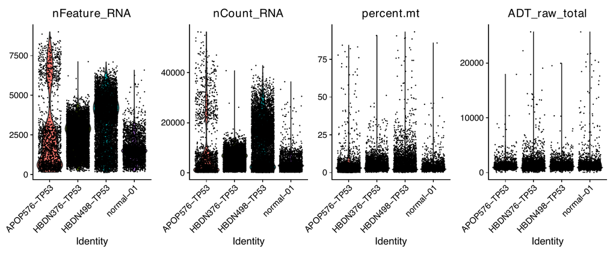

**`04_raw_ADT_marker_distributions.pdf`**

Raw ADT counts per marker, before any normalisation - the ambient signal is what makes these unusable as they stand.

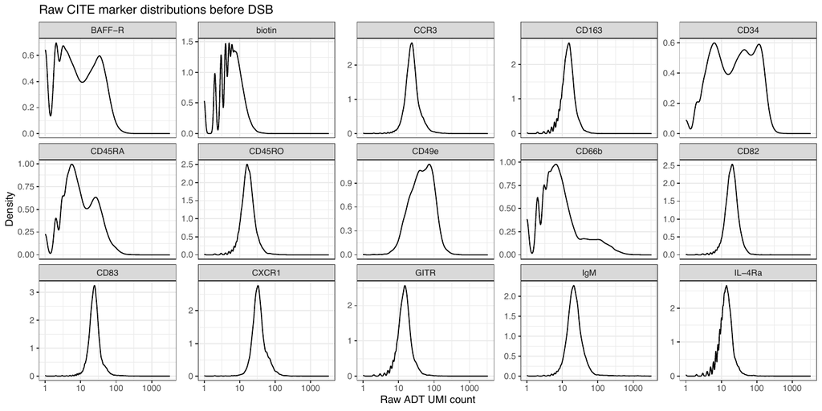

**`05_CLR_ADT_marker_distributions.pdf`**

The same markers after CLR.

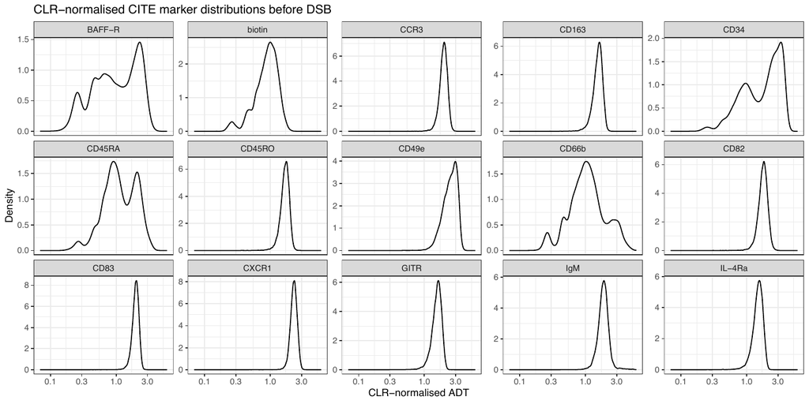

**`06_RNA_umap_QC.pdf`**

RNA UMAP used for the overlays below.

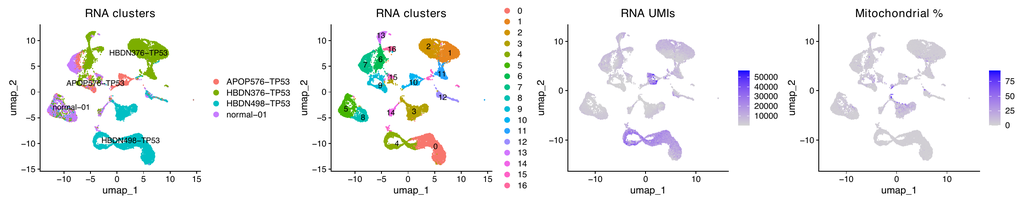

**`07_CLR_ADT_featureplots_top_markers.pdf`**

Top markers under CLR on the RNA UMAP.

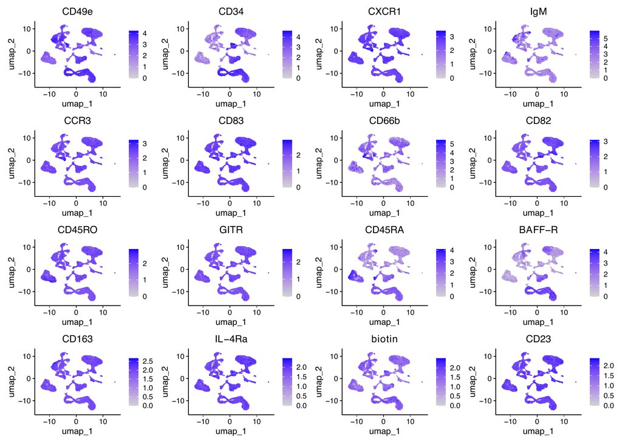

**`08_CLR_ADT_discriminative_markers.pdf`**

The most discriminative markers under CLR.

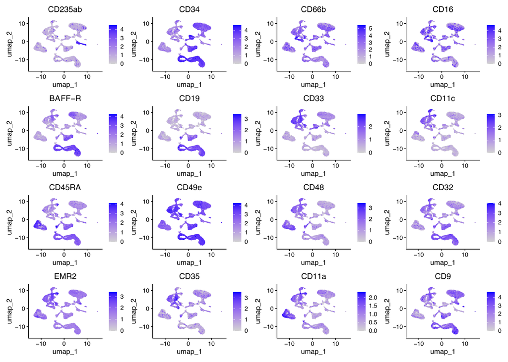

**`09_CLR_heatmap_by_RNA_cluster.pdf`**

CLR signal by RNA cluster.

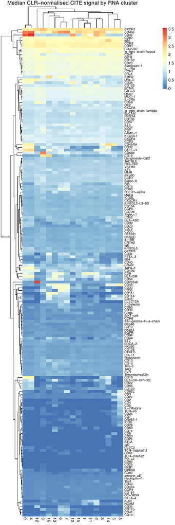

**`11_CITE_marker_CLR_positive_cells_by_sample.pdf`**

Positive cells per marker per sample under CLR.

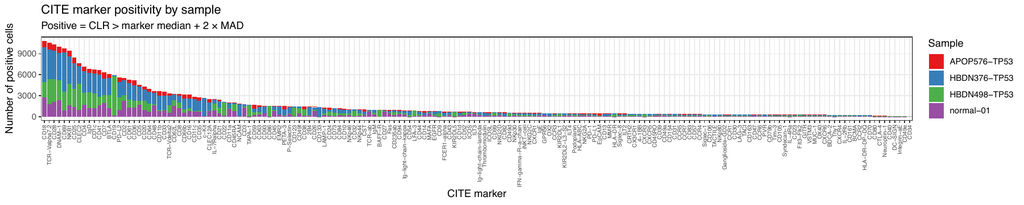

# 3. Background and the isotype controls

DSB estimates background from empty droplets and then removes per-cell technical noise using the isotype controls. Step 04 checks that estimate is not an artefact of which isotypes happen to be in the panel, by subsampling them 30 times at random and re-deriving the background.

**`dsb_igg_reduction_subsampling.pdf`**

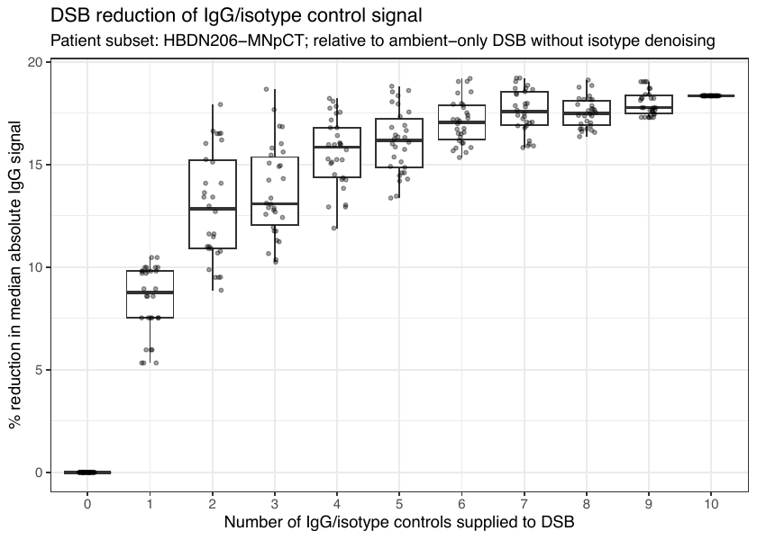

# 4. DSB against CLR

Step 05 is the head-to-head, on HBDN206-MNpCT.

**`01_marker_mean_shift_DSB_minus_CLR.pdf`**

Per-marker mean shift, DSB minus CLR. Markers above zero gained signal relative to background under DSB.

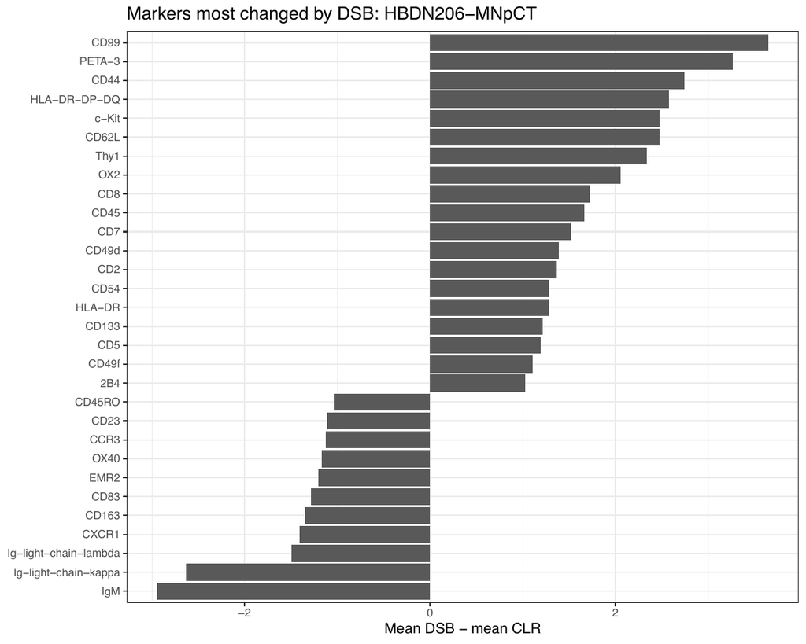

01_marker_mean_shift_DSB_minus_CLR.csv

| marker | mean_CLR | mean_DSB | delta_DSB_minus_CLR |
| --- | --- | --- | --- |
| CD99 | 2.4733357 | 6.121970 | 3.6486344 |
| PETA-3 | 1.7992250 | 5.067465 | 3.2682404 |
| CD44 | 1.1138270 | 3.859165 | 2.7453384 |
| HLA-DR-DP-DQ | 1.8277369 | 4.404731 | 2.5769940 |
| c-Kit | 1.6256641 | 4.105634 | 2.4799703 |
| CD62L | 0.4517879 | 2.930737 | 2.4789489 |
| Thy1 | 0.9490599 | 3.285325 | 2.3362655 |
| OX2 | 1.9921708 | 4.052448 | 2.0602776 |
| CD8 | 0.1453581 | 1.865855 | 1.7204967 |
| CD45 | 1.1898704 | 2.858192 | 1.6683214 |
| CD7 | 0.2110062 | 1.730692 | 1.5196859 |
| CD49d | 1.5273281 | 2.914218 | 1.3868901 |
| CD2 | 0.2679553 | 1.638304 | 1.3703489 |
| CD54 | 1.1613030 | 2.443034 | 1.2817307 |
| HLA-DR | 2.3262512 | 3.603977 | 1.2777256 |
| CD133 | 1.8782080 | 3.090959 | 1.2127506 |
| CD5 | 0.1962089 | 1.391183 | 1.1949738 |
| CD49f | 1.0096267 | 2.116237 | 1.1066101 |
| 2B4 | 1.4927637 | 2.517694 | 1.0249307 |
| CD123 | 1.0154373 | 1.879796 | 0.8643584 |
| CD43 | 1.1120502 | 1.948497 | 0.8364467 |
| CD31 | 0.8965285 | 1.686168 | 0.7896394 |
| PVR | 0.9623402 | 1.745876 | 0.7835355 |
| CD10 | 0.4660673 | 1.240779 | 0.7747115 |
| CD9 | 1.7797975 | 2.527111 | 0.7473134 |

02_RNA_protein_correlation_DSB_vs_CLR.csv

| marker | gene | cor_CLR | cor_DSB | delta_DSB_minus_CLR |
| --- | --- | --- | --- | --- |
| CD83 | CD8A | -0.1190512 | -0.0354092 | 0.0836420 |
| CD82 | CD8A | -0.1981759 | -0.1319100 | 0.0662658 |
| CD33 | CD3D | -0.0941080 | -0.0503718 | 0.0437362 |
| CD31 | CD3D | -0.1522775 | -0.1096032 | 0.0426744 |
| CD38 | CD3D | 0.0701710 | 0.1116796 | 0.0415085 |
| CD163 | FCGR3A | -0.0408244 | -0.0094500 | 0.0313744 |
| CD30 | CD3D | -0.0314646 | -0.0059678 | 0.0254968 |
| CD45RA | PTPRC | 0.0409043 | 0.0654681 | 0.0245638 |
| CD45RO | PTPRC | 0.1257468 | 0.1462185 | 0.0204717 |
| CCR7 | CCR7 | -0.0015805 | 0.0176101 | 0.0191906 |
| OX40 | TNFRSF4 | 0.0331584 | 0.0506588 | 0.0175005 |
| CD34 | CD3D | -0.2802171 | -0.2627862 | 0.0174309 |
| CXCR1 | CXCR1 | 0.0291581 | 0.0449373 | 0.0157792 |
| CD32 | CD3D | -0.0053044 | 0.0101965 | 0.0155010 |
| CD83 | CD83 | 0.0018763 | 0.0138721 | 0.0119958 |
| CD39 | CD3D | 0.0167410 | 0.0279230 | 0.0111820 |
| CD35 | CD3D | -0.0161583 | -0.0050585 | 0.0110998 |
| CD49e | CD4 | 0.0713485 | 0.0822681 | 0.0109196 |
| CD48 | CD4 | 0.0072876 | 0.0177751 | 0.0104875 |
| CD45RO | CD4 | 0.0107044 | 0.0199771 | 0.0092727 |
| CD49a | CD4 | 0.0029852 | 0.0120500 | 0.0090647 |
| IL-2Rb | IL2RB | 0.1289432 | 0.1375641 | 0.0086208 |
| CD4 | CD4 | 0.0869039 | 0.0948451 | 0.0079412 |
| CD41 | CD4 | 0.0225840 | 0.0297711 | 0.0071870 |
| CD47 | CD47 | 0.0245270 | 0.0313452 | 0.0068182 |

The specificity score behind the conclusion is **mean of the expected population divided by median background**, computed per marker against a hand-curated panel: CD163, CD14, CD33 and CD11b for myeloid/DC; CD34, CD117 and CD133 for stem/progenitor; CD4, CD8, CD19 and CD20 for lymphoid; CD71 for erythroid. Cells are called positive at 3 SD over background.

# 5. Unmapped ADT reads

**Read this section for what it is.** Step 06 was run with `input_mode <- "full_fastq"` against the entire LK2 ADT R2 file, not against the unmapped reads. Everything below therefore describes the whole library, and is a check that the tag reference and read structure are right - which they are. It is not a diagnosis of the unmapped reads.

The unmapped reads are separately accounted for. CITE-seq-Count’s own `run_report.yaml` puts mapping at **97%** for ADT and **95%** for HTO, and its `unmapped.csv` shows what the remainder is:

| Run / library | Poly-G share of the top-100 unmapped |
| --- | --- |
| Pilot ADT (`260423`, LK1) | 99.9% |
| Pilot HTO (`260423`, LK1) | 98.9% |
| LK2 ADT (`260528`) | 67.5% |

Those sequences are 90 bases of `G`. On two-colour chemistry a dark or failed cluster is base-called as G, so this is empty flowcell rather than anything about the antibodies, the reference or the droplets. `unmapped.csv` lists only the top 100 sequences, so this characterises the dominant species rather than every unmapped read - and the LK2 figure of 67.5% means a third of its unmapped reads are something else, which has not been looked at.

**`edit_distance_histogram.pdf`**

Edit distance from each observed barcode to the nearest known tag. A pile-up at distance 1-2 means sequencing error; a pile-up further out means the observed sequences are not the tags at all.

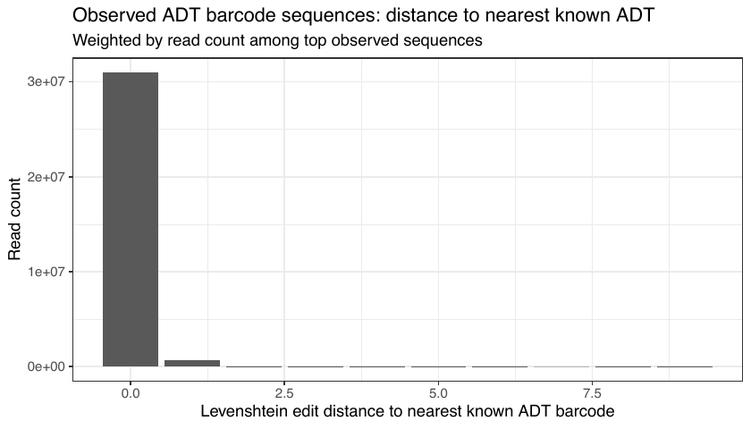

**`top_observed_barcodes.pdf`**

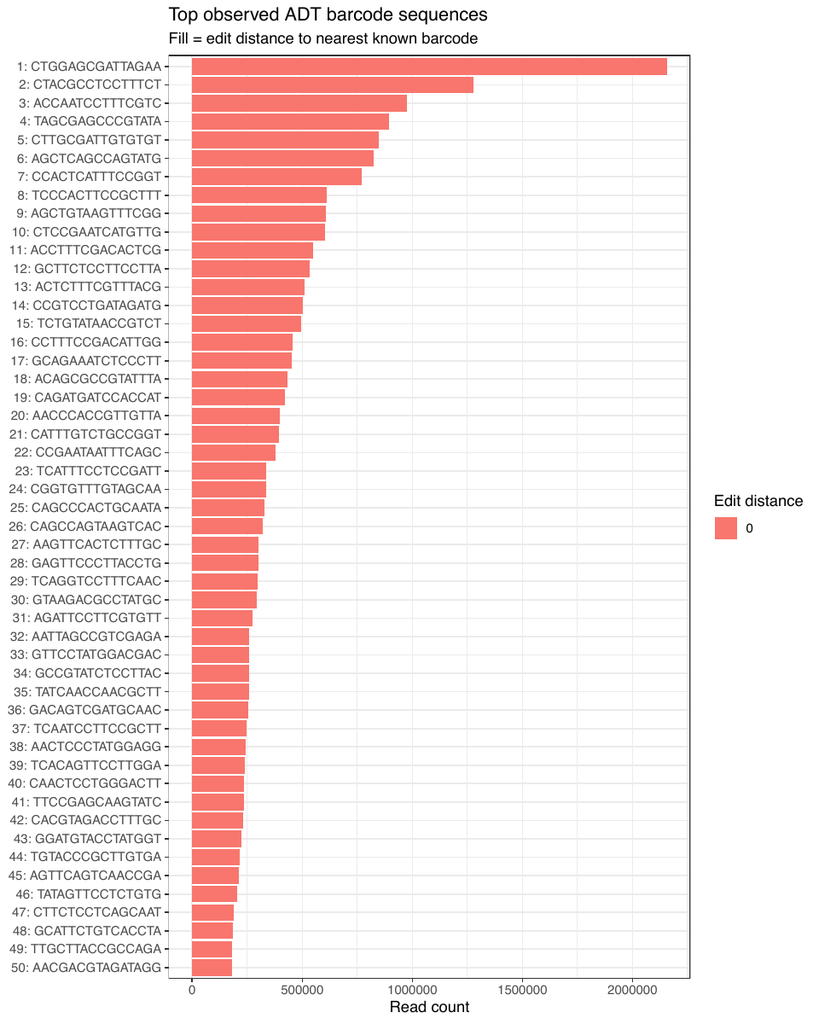

observed_barcode_counts.csv

| observed_sequence | read_count | rank | pct_reads |
| --- | --- | --- | --- |
| CTGGAGCGATTAGAA | 2155592 | 1 | 6.492747 |
| CTACGCCTCCTTTCT | 1278629 | 2 | 3.851292 |
| ACCAATCCTTTCGTC | 973419 | 3 | 2.931985 |
| TAGCGAGCCCGTATA | 894278 | 4 | 2.693608 |
| CTTGCGATTGTGTGT | 848714 | 5 | 2.556367 |
| AGCTCAGCCAGTATG | 825766 | 6 | 2.487247 |
| CCACTCATTTCCGGT | 768091 | 7 | 2.313527 |
| TCCCACTTCCGCTTT | 611319 | 8 | 1.841322 |
| AGCTGTAAGTTTCGG | 607190 | 9 | 1.828885 |
| CTCCGAATCATGTTG | 602057 | 10 | 1.813425 |
| ACCTTTCGACACTCG | 547159 | 11 | 1.648069 |
| GCTTCTCCTTCCTTA | 532205 | 12 | 1.603027 |
| ACTCTTTCGTTTACG | 509711 | 13 | 1.535274 |
| CCGTCCTGATAGATG | 502076 | 14 | 1.512277 |
| TCTGTATAACCGTCT | 493087 | 15 | 1.485202 |
| CCTTTCCGACATTGG | 455018 | 16 | 1.370536 |
| GCAGAAATCTCCCTT | 451726 | 17 | 1.360621 |
| ACAGCGCCGTATTTA | 434361 | 18 | 1.308316 |
| CAGATGATCCACCAT | 420574 | 19 | 1.266789 |
| AACCCACCGTTGTTA | 398800 | 20 | 1.201205 |

observed_vs_known_distance.csv

| observed_sequence | read_count | rank | pct_reads | nearest_known_sequence | nearest_antibody | edit_distance | exact_match | near_match |
| --- | --- | --- | --- | --- | --- | --- | --- | --- |
| CTGGAGCGATTAGAA | 2155592 | 1 | 6.492747 | CTGGAGCGATTAGAA | IgG_Fc | 0 | TRUE | TRUE |
| CTACGCCTCCTTTCT | 1278629 | 2 | 3.851292 | CTACGCCTCCTTTCT | CXCR1 | 0 | TRUE | TRUE |
| ACCAATCCTTTCGTC | 973419 | 3 | 2.931985 | ACCAATCCTTTCGTC | CCR3 | 0 | TRUE | TRUE |
| TAGCGAGCCCGTATA | 894278 | 4 | 2.693608 | TAGCGAGCCCGTATA | IgM | 0 | TRUE | TRUE |
| CTTGCGATTGTGTGT | 848714 | 5 | 2.556367 | CTTGCGATTGTGTGT | CD49e | 0 | TRUE | TRUE |
| AGCTCAGCCAGTATG | 825766 | 6 | 2.487247 | AGCTCAGCCAGTATG | Ig_light_chain_kappa | 0 | TRUE | TRUE |
| CCACTCATTTCCGGT | 768091 | 7 | 2.313527 | CCACTCATTTCCGGT | CD83 | 0 | TRUE | TRUE |
| TCCCACTTCCGCTTT | 611319 | 8 | 1.841322 | TCCCACTTCCGCTTT | CD82 | 0 | TRUE | TRUE |
| AGCTGTAAGTTTCGG | 607190 | 9 | 1.828885 | AGCTGTAAGTTTCGG | CD66b | 0 | TRUE | TRUE |
| CTCCGAATCATGTTG | 602057 | 10 | 1.813425 | CTCCGAATCATGTTG | CD45RO | 0 | TRUE | TRUE |
| ACCTTTCGACACTCG | 547159 | 11 | 1.648069 | ACCTTTCGACACTCG | GITR | 0 | TRUE | TRUE |
| GCTTCTCCTTCCTTA | 532205 | 12 | 1.603027 | GCTTCTCCTTCCTTA | CD163 | 0 | TRUE | TRUE |
| ACTCTTTCGTTTACG | 509711 | 13 | 1.535274 | ACTCTTTCGTTTACG | Syndecan_1 | 0 | TRUE | TRUE |
| CCGTCCTGATAGATG | 502076 | 14 | 1.512277 | CCGTCCTGATAGATG | IL-4Ra | 0 | TRUE | TRUE |
| TCTGTATAACCGTCT | 493087 | 15 | 1.485202 | TCTGTATAACCGTCT | CD23 | 0 | TRUE | TRUE |
| CCTTTCCGACATTGG | 455018 | 16 | 1.370536 | CCTTTCCGACATTGG | CCR1 | 0 | TRUE | TRUE |
| GCAGAAATCTCCCTT | 451726 | 17 | 1.360621 | GCAGAAATCTCCCTT | CD34 | 0 | TRUE | TRUE |
| ACAGCGCCGTATTTA | 434361 | 18 | 1.308316 | ACAGCGCCGTATTTA | PD-1 | 0 | TRUE | TRUE |
| CAGATGATCCACCAT | 420574 | 19 | 1.266789 | CAGATGATCCACCAT | BCMA | 0 | TRUE | TRUE |
| AACCCACCGTTGTTA | 398800 | 20 | 1.201205 | AACCCACCGTTGTTA | OX40 | 0 | TRUE | TRUE |

reverse_complement_distance.csv

| read_count | rank | pct_reads | observed_sequence | nearest_known_sequence | nearest_antibody | edit_distance | exact_match | near_match |
| --- | --- | --- | --- | --- | --- | --- | --- | --- |
| 2155592 | 1 | 6.492747 | TTCTAATCGCTCCAG | ATCACATCGTTGCCA | PVR | 6 | FALSE | FALSE |
| 1278629 | 2 | 3.851292 | AGAAAGGAGGCGTAG | AGCTACGAGCAGTAG | HLA-DR_DP_DQ | 5 | FALSE | FALSE |
| 973419 | 3 | 2.931985 | GACGAAAGGATTGGT | GACAAGTGATCTGCA | CD11b | 6 | FALSE | FALSE |
| 894278 | 4 | 2.693608 | TATACGGGCTCGCTA | TATGCGAGGCTTATC | HLA-ABC | 6 | FALSE | FALSE |
| 848714 | 5 | 2.556367 | ACACACAATCGCAAG | GACAGTCGATGCAAC | CXCR6 | 6 | FALSE | FALSE |
| 825766 | 6 | 2.487247 | CATACTGGCTGAGCT | CAACTCCTGGGACTT | NKG2A | 6 | FALSE | FALSE |
| 768091 | 7 | 2.313527 | ACCGGAAATGAGTGG | ACGAATCAATCTGTG | CD80 | 7 | FALSE | FALSE |
| 611319 | 8 | 1.841322 | AAAGCGGAAGTGGGA | AATAGCGAGCAAGTA | HLA-DR | 6 | FALSE | FALSE |
| 607190 | 9 | 1.828885 | CCGAAACTTACAGCT | CCGAATAATTTCAGC | MUC-1 | 4 | FALSE | FALSE |
| 602057 | 10 | 1.813425 | CAACATGATTCGGAG | CAGTAAGTTCGGGAC | 4-1BB | 6 | FALSE | FALSE |
| 547159 | 11 | 1.648069 | CGAGTGTCGAAAGGT | GGATGTACCTATGGT | EMR2 | 6 | FALSE | FALSE |
| 532205 | 12 | 1.603027 | TAAGGAAGGAGAAGC | AACGACGTAGATAGG | ILT4 | 6 | FALSE | FALSE |
| 509711 | 13 | 1.535274 | CGTAAACGAAAGAGT | CGTAACGTAGAGCGA | TCR_ab | 5 | FALSE | FALSE |
| 502076 | 14 | 1.512277 | CATCTATCAGGACGG | CAGCCATTCATTAGG | CD10 | 6 | FALSE | FALSE |
| 493087 | 15 | 1.485202 | AGACGGTTATACAGA | AGACTAATAGCTGAC | c-Kit | 6 | FALSE | FALSE |
| 455018 | 16 | 1.370536 | CCAATGTCGGAAAGG | ACAATTTGAACAGCG | NKp46 | 6 | FALSE | FALSE |
| 451726 | 17 | 1.360621 | AAGGGAGATTTCTGC | CACGTAGACCTTTGC | OX2 | 6 | FALSE | FALSE |
| 434361 | 18 | 1.308316 | TAAATACGGCGCTGT | TAACTCAGGGCCTAT | CD33 | 5 | FALSE | FALSE |
| 420574 | 19 | 1.266789 | ATGGTGGATCATCTG | ATCGTCGAGAGCTAG | CD105 | 6 | FALSE | FALSE |
| 398800 | 20 | 1.201205 | TAACAACGGTGGGTT | TATCAACCAACGCTT | KIR2DL1 | 6 | FALSE | FALSE |

To diagnose the unmapped reads properly, step 06 would be re-run with `input_mode <- "unmapped_fastq"` against the unmapped output from step 02 (`cite_seq_count/<run>/unmapped_tags_<sample>.csv`).

# 6. What was run, in order

[output not shown]

`scripts/7d.DSB_cluster_resolution.R` is not a separate step: it is step 05 re-pointed at LK2, differing by twelve lines that are all run and sample variables. Change `run`, `sample_name` and `sample_short` in step 05 to reproduce it. Its name is misleading - it is not a cluster-resolution analysis.

# 7. Data locations

| What | Location |
| --- | --- |
| ADT counts | `results/cite_seq_count/<run>/adt_counts_*/` |
| CITE QC and DSB | `results/cite_seq_dsb/<run>/` |
| Earlier QC-then-DSB outputs | `results/benchmarking/cite_qc_then_dsb/` |
| Isotype subsampling | `results/benchmarking/dsb_igg_subsample/` |
| DSB vs CLR | `results/seurat_annotated/<run>/projectionFigures/DSB_vs_CLR_<donor>/` |
| Unmapped diagnostics | `results/adt_unmapped_diagnostics/` and `results/adt_unmapped_investigator/` |

# 8. Tools

| Tool | Version | Source |
| --- | --- | --- |
| CITE-seq-Count | to confirm | steps 01 and 02 |
| dsb | see session below | denoised and scaled by background |
| Seurat CLR | see session below | comparison baseline |

# 9. Caveats

1. **The residual CITE analysis is not included.** `scripts/13.CITE_residuals.R` belongs to this period but cannot be run as written - it never loads an object, expecting `seu_dsb` and `celltype_cols` to exist in the session already - and its output directory `results/benchmarking/residual_cite_analysis` is empty. It will be added once it has been run.
2. **The CLR-vs-DSB comparison is one donor**, HBDN206-MNpCT on the pilot run. The LK2 equivalent exists only as the re-pointed script noted above.
3. **CellBender does not touch the protein data** in the current pipeline, since the Cell Ranger matrix is `Gene Expression` only. Whether ambient protein removal before DSB helps is a separate question, and is not tested here.